# COMPSCIX 415.2 – Jackie Lang Homework 4

## 5.6.7.2

Come up with another approach that will give you the same output as not_cancelled %>% count(dest) and not_cancelled %>% count(tailnum, wt = distance) (without using count()).

Output for flights which are not cancelled, arranged by destination (not using count ():

```r
flights %>%
  group_by(dest) %>%
  summarize(not_cancelled = sum(!is.na(dep_time)))
```

```
## # A tibble: 105 x 2
##    dest  not_cancelled
##    <chr>         <int>
##  1 ABQ             254
##  2 ACK             265
##  3 ALB             419
##  4 ANC               8
##  5 ATL           16898
##  6 AUS            2418
##  7 AVL             263
##  8 BDL             412
##  9 BGR             360
## 10 BHM             272
## # ... with 95 more rows
```

Flights which have not been cancelled, grouped by tail number and with distance (not using count ()):

```r
flights %>%
  group_by(tailnum) %>%
  summarize(not_cancelled = sum(!is.na(dep_time)),
            distance= sum(distance))
```

```
## # A tibble: 4,044 x 3
##    tailnum not_cancelled distance
##    <chr>           <int>    <dbl>
##  1 D942DN              4     3418
##  2 N0EGMQ            354   250866
##  3 N10156            146   115966
##  4 N102UW             48    25722
##  5 N103US             46    24619
##  6 N104UW             47    25157
##  7 N10575            272   150194
##  8 N105UW             45    23618
##  9 N107US             41    21677
## 10 N108UW             60    32070
## # ... with 4,034 more rows
```

## 5.6.7.4

In terms of cancelled flights per day, there doesn’t seem to be a direct relationship between the number of cancelled flights per day, except that it is possible that there may be a cascading effect due to an outside force, such as a weather event. This did not appear to be a very strong relationship.

The number of cancelled flights per day, from the flights data:

```r
flights %>%
  group_by(year, month, day) %>%
  summarize(cancelled = sum(is.na(dep_time)))
```

```
## # A tibble: 365 x 4
## # Groups:   year, month [?]
##     year month   day cancelled
##    <int> <int> <int>     <int>
##  1  2013     1     1         4
##  2  2013     1     2         8
##  3  2013     1     3        10
##  4  2013     1     4         6
##  5  2013     1     5         3
##  6  2013     1     6         1
##  7  2013     1     7         3
##  8  2013     1     8         4
##  9  2013     1     9         5
## 10  2013     1    10         3
## # ... with 355 more rows
```

Then, looking at the delay arranged by individual tail number:

```r
flights %>%
  group_by(tailnum) %>%
  summarize(
    delay = mean(arr_delay, na.rm = TRUE),
    n = n())
```

```
## # A tibble: 4,044 x 3
##    tailnum   delay     n
##    <chr>     <dbl> <int>
##  1 D942DN   31.5       4
##  2 N0EGMQ    9.98    371
##  3 N10156   12.7     153
##  4 N102UW    2.94     48
##  5 N103US  - 6.93     46
##  6 N104UW    1.80     47
##  7 N10575   20.7     289
##  8 N105UW  - 0.267    45
##  9 N107US  - 5.73     41
## 10 N108UW  - 1.25     60
## # ... with 4,034 more rows
```

The proportion of cancelled flights related to the average delay:

```r
flights %>% mutate(cancelled = (is.na(dep_time) | is.na(arr_time))) %>%
                     group_by(month, day) %>%
            summarize(cancelled = sum(is.na(dep_delay)),
            n = n(),
            mean_dep_delay = mean(dep_delay,na.rm=TRUE),
            mean_arr_delay = mean(arr_delay,na.rm=TRUE))
```

```
## # A tibble: 365 x 6
## # Groups:   month [?]
##    month   day cancelled     n mean_dep_delay mean_arr_delay
##    <int> <int>     <int> <int>          <dbl>          <dbl>
##  1     1     1         4   842          11.5          12.7
##  2     1     2         8   943          13.9          12.7
##  3     1     3        10   914          11.0           5.73
##  4     1     4         6   915           8.95        - 1.93
##  5     1     5         3   720           5.73        - 1.53
##  6     1     6         1   832           7.15          4.24
##  7     1     7         3   933           5.42        - 4.95
##  8     1     8         4   899           2.55        - 3.23
##  9     1     9         5   902           2.28        - 0.264
## 10     1    10         3   932           2.84        - 5.90
## # ... with 355 more rows
```

There does appear to be a loose connection between the number of cancelled flights relative to the average delay, as seen in the plot below. I included geom_smooth () to demonstrate the pattern on the relationship. This proportional relationship does appear stronger than the cancellations per individual day.

Plot:

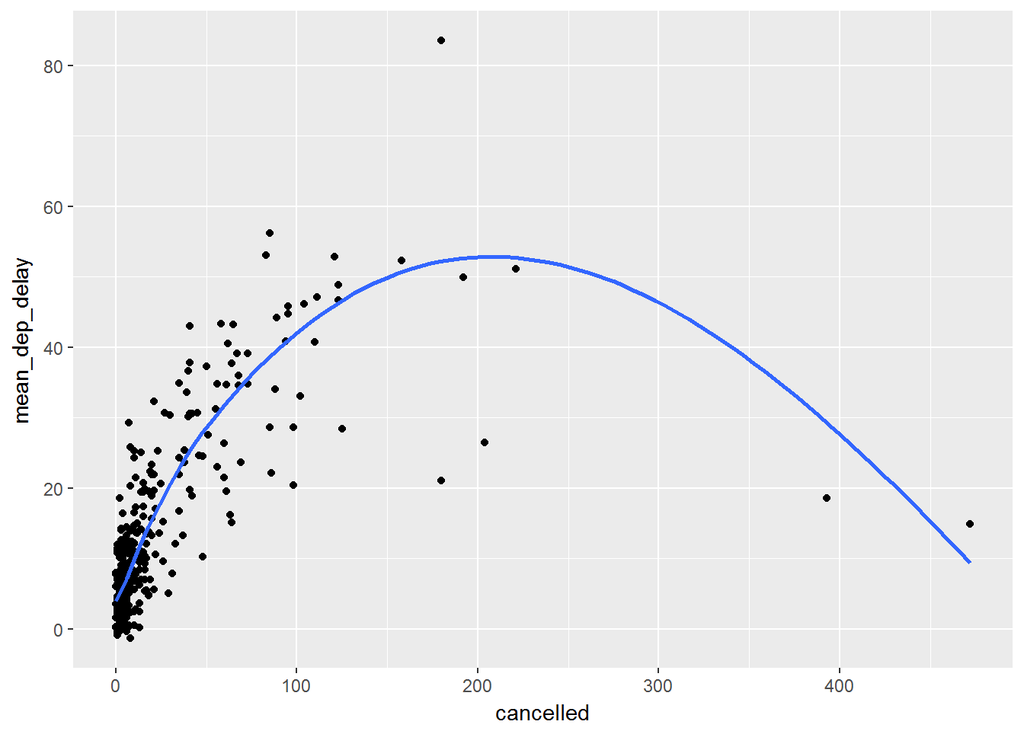

```r
flights %>% mutate(cancelled = (is.na(dep_time) | is.na(arr_time))) %>%
  group_by(year,month, day) %>%
            summarize(cancelled = sum(is.na(dep_time)),
            n = n(),
            mean_dep_delay = mean(dep_delay,na.rm=TRUE),
            mean_arr_delay = mean(arr_delay,na.rm=TRUE)) %>%
    ggplot(mapping = aes(x = cancelled, y = mean_dep_delay)) +
  geom_point(alpha = 1) +
  geom_smooth(se = FALSE)
```

## 5.6.7.5

The Carrier with the worst delays is “OO”, looking at the average arrival and departure delays:

```r
flights %>%
  filter(arr_delay > 0) %>%
  group_by(carrier) %>%
  summarize(avg_arr_delay = mean(arr_delay, na.rm = TRUE),
            avg_dep_delay = mean(dep_delay, na.rm = TRUE)) %>%
  arrange(desc(avg_arr_delay))
```

```
## # A tibble: 16 x 3
##    carrier avg_arr_delay avg_dep_delay
##    <chr>           <dbl>         <dbl>
##  1 OO               60.6          50.2
##  2 YV               51.1          45.4
##  3 9E               49.3          47.3
##  4 EV               48.3          45.2
##  5 F9               47.6          35.9
##  6 VX               43.8          38.1
##  7 FL               41.1          33.4
##  8 WN               40.7          39.4
##  9 B6               40.0          33.2
## 10 AA               38.3          31.2
## 11 MQ               37.9          28.1
## 12 DL               37.7          30.8
## 13 UA               36.7          32.1
## 14 HA               35.0          26.0
## 15 AS               34.4          31.8
## 16 US               29.0          18.3
```

Looking at the relationship between carrier and airport, it appears there is a stronger association between carrier and delay rather than airport and delay. However, this doesn’t appear to be a very strong relationship, and it’s difficult to untangle.

```r
flights %>%
  group_by(carrier, dest) %>%
  summarize(avg_arr_delay = mean(arr_delay, na.rm = TRUE),
            avg_dep_delay = mean(dep_delay, na.rm = TRUE)) %>%
  arrange(desc(avg_arr_delay))
```

```
## # A tibble: 314 x 4
## # Groups:   carrier [16]
##    carrier dest  avg_arr_delay avg_dep_delay
##    <chr>   <chr>         <dbl>         <dbl>
##  1 UA      STL           110            77.5
##  2 OO      ORD           107            67.0
##  3 OO      DTW            68.5          61.0
##  4 UA      RDU            56.0          60.0
##  5 EV      CAE            42.8          36.7
##  6 EV      TYS            41.2          41.8
##  7 EV      PBI            40.7          48.7
##  8 EV      TUL            33.7          34.9
##  9 EV      OKC            30.6          30.6
## 10 UA      JAC            29.9          28.7
## # ... with 304 more rows
```

## 5.6.7.6

The sort argument to count can be used to sort the output in the decending order of n, if n is TRUE. This is may be more useful than count() in some places because it will allow the programmer to see the highest value at the top, which is often valuable information. Count () is generally used just to measure the number of observations.

## 10.5.1

You can tell an object is a tibble rather than a data frame through two key differences: 1. The tibble will return what will fit on your screen. That is, it won’t print out the entire data set, only the first 10 rows or so and only the number of columns that will fit on your screen. It will also report the column type on the screen. 2. The other difference is how you subset variables. Also, tibbles will only return whole values, and not partial values (it will throw a warning if you try this).

See the mtcars data.frame below:

```r
print(mtcars)
```

```
##                      mpg cyl  disp  hp drat    wt  qsec vs am gear carb
## Mazda RX4           21.0   6 160.0 110 3.90 2.620 16.46  0  1    4    4
## Mazda RX4 Wag       21.0   6 160.0 110 3.90 2.875 17.02  0  1    4    4
## Datsun 710          22.8   4 108.0  93 3.85 2.320 18.61  1  1    4    1
## Hornet 4 Drive      21.4   6 258.0 110 3.08 3.215 19.44  1  0    3    1
## Hornet Sportabout   18.7   8 360.0 175 3.15 3.440 17.02  0  0    3    2
## Valiant             18.1   6 225.0 105 2.76 3.460 20.22  1  0    3    1
## Duster 360          14.3   8 360.0 245 3.21 3.570 15.84  0  0    3    4
## Merc 240D           24.4   4 146.7  62 3.69 3.190 20.00  1  0    4    2
## Merc 230            22.8   4 140.8  95 3.92 3.150 22.90  1  0    4    2
## Merc 280            19.2   6 167.6 123 3.92 3.440 18.30  1  0    4    4
## Merc 280C           17.8   6 167.6 123 3.92 3.440 18.90  1  0    4    4
## Merc 450SE          16.4   8 275.8 180 3.07 4.070 17.40  0  0    3    3
## Merc 450SL          17.3   8 275.8 180 3.07 3.730 17.60  0  0    3    3
## Merc 450SLC         15.2   8 275.8 180 3.07 3.780 18.00  0  0    3    3
## Cadillac Fleetwood  10.4   8 472.0 205 2.93 5.250 17.98  0  0    3    4
## Lincoln Continental 10.4   8 460.0 215 3.00 5.424 17.82  0  0    3    4
## Chrysler Imperial   14.7   8 440.0 230 3.23 5.345 17.42  0  0    3    4
## Fiat 128            32.4   4  78.7  66 4.08 2.200 19.47  1  1    4    1
## Honda Civic         30.4   4  75.7  52 4.93 1.615 18.52  1  1    4    2
## Toyota Corolla      33.9   4  71.1  65 4.22 1.835 19.90  1  1    4    1
## Toyota Corona       21.5   4 120.1  97 3.70 2.465 20.01  1  0    3    1
## Dodge Challenger    15.5   8 318.0 150 2.76 3.520 16.87  0  0    3    2
## AMC Javelin         15.2   8 304.0 150 3.15 3.435 17.30  0  0    3    2
## Camaro Z28          13.3   8 350.0 245 3.73 3.840 15.41  0  0    3    4
## Pontiac Firebird    19.2   8 400.0 175 3.08 3.845 17.05  0  0    3    2
## Fiat X1-9           27.3   4  79.0  66 4.08 1.935 18.90  1  1    4    1
## Porsche 914-2       26.0   4 120.3  91 4.43 2.140 16.70  0  1    5    2
## Lotus Europa        30.4   4  95.1 113 3.77 1.513 16.90  1  1    5    2
## Ford Pantera L      15.8   8 351.0 264 4.22 3.170 14.50  0  1    5    4
## Ferrari Dino        19.7   6 145.0 175 3.62 2.770 15.50  0  1    5    6
## Maserati Bora       15.0   8 301.0 335 3.54 3.570 14.60  0  1    5    8
## Volvo 142E          21.4   4 121.0 109 4.11 2.780 18.60  1  1    4    2
```

## 10.5.2

Observing the behavior of these commands, several parts are frustrating from the data frame.

Firstly, querying the data frame returns a partial value when I search for “x,” it gives back the column value “xyz”, and I get the same result when I search for the whole column “xyz.” I get an error when I do the same query ($x) in the tibble, which requires exact values when returning a subset.

Also the tibble returns include the size of the table and the data types, which are useful. Please see the examples below:

On data.frame: > df$x #returns [1] a Levels: a

> df[, “xyz”] #returns [1] a Levels: a

> df[, c(“abc”, “xyz”)] #returns abc xyz 1 1 a

on tibble: > df$x #returns NULL Warning message: Unknown or uninitialised column: ‘x’.

> df[, “xyz”] #returns # A tibble: 1 x 1 xyz  
> 1 a

> df[, c(“abc”, “xyz”)] #returns # A tibble: 1 x 2 abc xyz  
> 1 1.00 a

## 10.5.3

To extract the reference variable, query it using [[]]:

```r
var <- "mpg"
as_tibble(mtcars)[[var]]
```

```
##  [1] 21.0 21.0 22.8 21.4 18.7 18.1 14.3 24.4 22.8 19.2 17.8 16.4 17.3 15.2
## [15] 10.4 10.4 14.7 32.4 30.4 33.9 21.5 15.5 15.2 13.3 19.2 27.3 26.0 30.4
## [29] 15.8 19.7 15.0 21.4
```

## 10.5.6

The package option: tibble.max_extra_cols controls the number of extra columns printed at the footer of the tibble. The default for this package is 100. (citation: https://cran.r-project.org/web/packages/tibble/tibble.pdf)

# 12.3.3.2

Because the column names are numbers, you have to add backticks for the names to be valid. The code should read: table4a %>% gather(`1999`, `2000`, key = “year”, value = “cases”)

# 12.3.3.3

Spreading this tibble fails because there are duplicate identifiers in rows 1 and 3. To fix the problem, adding a row id to group the name column and then using a spread function in key to create a new column from key (which contains both age and height data) will help (citation: https://github.com/tidyverse/tidyr/issues/296)

original tribble:

```r
people <- tribble(
  ~name,             ~key,    ~value,
  #-----------------|--------|------
  "Phillip Woods",   "age",       45,
  "Phillip Woods",   "height",   186,
  "Phillip Woods",   "age",       50,
  "Jessica Cordero", "age",       37,
  "Jessica Cordero", "height",   156
)
```

updated tribble with age and height columns spread:

```r
people %>%
  group_by(name) %>%
  mutate(group_row = 1:n()) %>%
  spread(key,value)
```

```
## # A tibble: 5 x 4
## # Groups:   name [2]
##   name            group_row   age height
## * <chr>               <int> <dbl>  <dbl>
## 1 Jessica Cordero         1  37.0     NA
## 2 Jessica Cordero         2  NA      156
## 3 Phillip Woods           1  45.0     NA
## 4 Phillip Woods           2  NA      186
## 5 Phillip Woods           3  50.0     NA
```

# 12.3.3.4

This table needs to be gathered in order to be tidy. The table should be:

original tribble:

```r
preg <- tribble(
  ~pregnant, ~male, ~female,
  "yes",     NA,    10,
  "no",      20,    12
)
```

gathered, the the variables pregnant, sex, and participants:

```r
preg %>%
  gather(male,female, key = "sex", value = "participants")
```

```
## # A tibble: 4 x 3
##   pregnant sex    participants
##   <chr>    <chr>         <dbl>
## 1 yes      male           NA
## 2 no       male           20.0
## 3 yes      female         10.0
## 4 no       female         12.0
```

## 12.4.3.1.1

The extra argument controls what happens when there are too many pieces, in the even that the sep is a character vector. There are three valid options: “warn” (the default action, emits a warning and drops extra values); “drop” (drop any extra values without a warning); and “merge” (only splits at most length(into) times).

The fill argument controls what happens when there aren’t *enough* pieces. The three valid options are: “warn” (the default action, emits a warning and fill from the right); “right” (fill with missing values on the right); and “left” (fill with missing values on the left).

For this toy dataset, there rare too many values as indicated by the warning…

```r
df <- tibble(x = c("a,b,c,", "d,e,f,g", "h,i,j")) %>%
  separate(x, c("one", "two", "three"))
```

```
## Warning: Too many values at 2 locations: 1, 2
```

So I used the extra argument to merge the values. When I used the default “warn”, I recieved the same warning message as I did with just the separate argument.

```r
df <- tibble(x = c("a,b,c,", "d,e,f,g", "h,i,j")) %>%
  separate(x, c("one", "two", "three"), extra = "merge")
```

For the second data set:

```r
df <- tibble(x = c("a,b,c", "d,e,", "f,g,i")) %>%
  separate(x, c("one", "two", "three"))
```

I could use a fill argument to supplement the tibble values:

```r
df <- tibble(x = c("a,b,c", "d,e,", "f,g,i")) %>%
  separate(x, c("one", "two", "three"), fill = "right")
```

## 12.4.3.1.2

The remove argument will remove the input column from the output data frame if set to TRUE. This may be helpful if the column is full of NULL or bad values, or if the data isn’t relevant to the data set and you don’t want to include it. If set to FALSE, it will retain the column, and this may be valuable to retain the column of values that were separated in the final data frame (citation: https://garrettgman.github.io/tidying/).

# QUESTIONS SECTION

Importing the file baby_names.txt:

```r
file_path <- 'C:/Users/jrlang/Desktop/baby_names.txt'
delim_data <- read_delim((file = file_path), delim = "|")
```

Glimpse the .txt file:

```r
my_data <- delim_data
glimpse(my_data)
```

```
## Observations: 30,000
## Variables: 5
## $ year <int> 1880, 1880, 1880, 1880, 1880, 1880, 1880, 1880, 1880, 188...
## $ sex  <chr> "F", "F", "F", "F", "F", "F", "F", "F", "F", "F", "F", "F...
## $ name <chr> "Mary", "Anna", "Emma", "Elizabeth", "Minnie", "Margaret"...
## $ n    <int> 7065, 2604, 2003, 1939, 1746, 1578, 1472, 1414, 1320, 128...
## $ prop <dbl> 0.072384329, 0.026679234, 0.020521700, 0.019865989, 0.017...
```

Export:

```r
write_rds(delim_data, path = 'C:/Users/jrlang/Desktop/baby_names.rds')
```

Importing rds file:

```r
file_path <- 'C:/Users/jrlang/Desktop/baby_names.rds'
baby_names <- readRDS(file = file_path, refhook = NULL)
```

Glimpse the .rds file:

```r
as_tibble(baby_names)
```

```
## # A tibble: 30,000 x 5
##     year sex   name          n   prop
##    <int> <chr> <chr>     <int>  <dbl>
##  1  1880 F     Mary       7065 0.0724
##  2  1880 F     Anna       2604 0.0267
##  3  1880 F     Emma       2003 0.0205
##  4  1880 F     Elizabeth  1939 0.0199
##  5  1880 F     Minnie     1746 0.0179
##  6  1880 F     Margaret   1578 0.0162
##  7  1880 F     Ida        1472 0.0151
##  8  1880 F     Alice      1414 0.0145
##  9  1880 F     Bertha     1320 0.0135
## 10  1880 F     Sarah      1288 0.0132
## # ... with 29,990 more rows
```

```r
baby <- as_tibble(baby_names)
```